# Graded Novelty Encoding Task - pilot analysis

# The paradigm

-Familiarization phase Participants see 5 stimuli repeated 8 times each. Stimuli consist of a 3x3 grid, with 5 random shapes (circle,triangle,square) placed randomly (any 9 cells) with random color (red,blue,yellow,green,orange,purple).

-Study phase Participants see the 5 familiar stimuli 5 times each (25) and 50 novel stimuli. They have to judge if the current stimulus is one of the familiars. The novels differ to a differing degree from the familiars: there is 5x2 (two for each familiar) that is wholly different (diffarr). 5x2 that has the same placement of random shapes (sarr), 5x2 same arrangement and shapes (sarrsha), 5x2 same arrangement and colors (sarrcol) 5x2 same arrangement, shapes and colors (colors are randomized, thus, these are not the same as the familiars - sarrshacol).

-Test phase Participants see the novels from the study phase and 50 new stimuli (sarr - 10, sarrsha - 10, etc.). Participants have to signal if they have already seen the current stimulus or it is wholly new. They had the option to signal “maybe”, but were asked to do this in moderation (maybe resp <= 20). These responses have been added to correct responses.

# Participants

The online task has been started a total of 152 times.

We excluded a total of 11 runs due to irregular data leaving 141 in the analysis.

We excluded some (6) runs as they missed more than 66 of 175 trials.

We also excluded 27 runs in which the participant produced less than 0.3 corrected recognition rate for familiars in the study phase.

We also excluded 12 participants as they overused “maybe” responses in the test phase (more than 25).

We also excluded 1 run(s) as only the first run is kept in the analysis from one participant.

This left a total of 95 participants.

Maybe responses [mean(±sd)] : 10.34375 ± 6.7493908

The sample had a mean(±sd) age of 24.7849462 ± 6.8665058.

The sample contained 78 women.

The histogram below shows the number of participants completing the task in a given hour of the day.

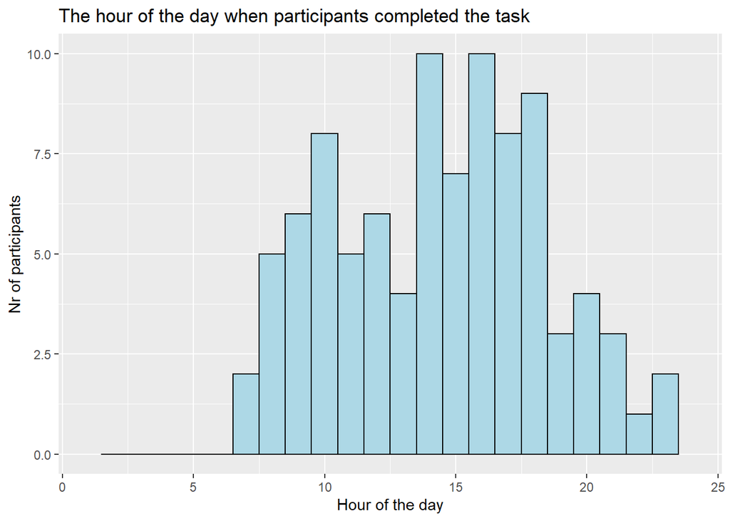

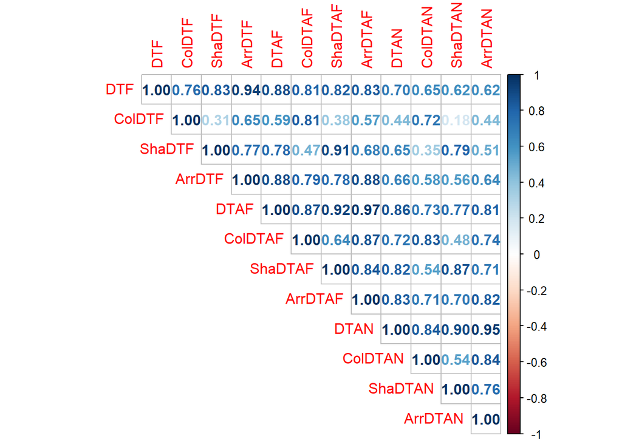

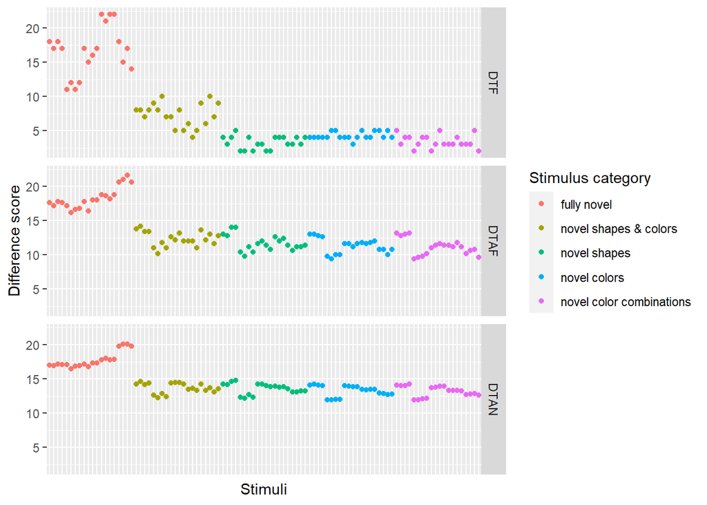

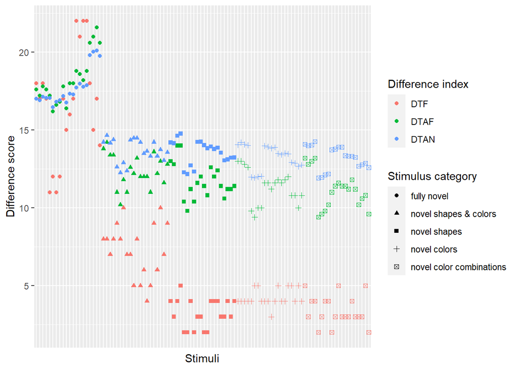

# Study phase:

During the study phase, the participants see familiar and novel items.

The participants produced a mean (±sd) recognition rate of 0.6597895 ± 0.1727094 for familiar pictures.

The participants produced a mean (±sd) corrected recognition rate of 0.3991579 ± 0.2194349 for familiar pictures.

Uncorrected: The sample performed above chance levels, as a one sample t-test showed (t(189)=12.7529032, p = 1.4018335^{-27}, Cohen’s d = 0.9251928, 95% CI:0.6240556 - 1.2263301).

Corrected: The sample performed above chance levels, as a one sample t-test showed (t(189)=25.0735516, p = 2.540164^{-62}, Cohen’s d = 1.8190266, 95% CI:1.4787317 - 2.1593216).

We use an ANOVA to see if there is a difference in correct rejection for the different novels.

```
## Anova Table (Type 3 tests)
##
## Response: N
##   Effect           df  MSE         F  ges p.value
## 1   type 3.57, 335.45 1.78 24.29 *** .095   <.001
## ---
## Signif. codes:  0 '***' 0.001 '**' 0.01 '*' 0.05 '+' 0.1 ' ' 1
##
## Sphericity correction method: GG
```

```
##  contrast             estimate    SE df t.ratio p.value
##  diffarr - sarr         0.8842 0.154 94   5.742  <.0001
##  diffarr - sarrcol      0.8632 0.166 94   5.188  <.0001
##  diffarr - sarrsha      1.8000 0.210 94   8.578  <.0001
##  diffarr - sarrshacol   0.8737 0.158 94   5.535  <.0001
##  sarr - sarrcol        -0.0211 0.163 94  -0.129  0.9999
##  sarr - sarrsha         0.9158 0.183 94   5.002  <.0001
##  sarr - sarrshacol     -0.0105 0.180 94  -0.059  1.0000
##  sarrcol - sarrsha      0.9368 0.209 94   4.485  0.0002
##  sarrcol - sarrshacol   0.0105 0.190 94   0.056  1.0000
##  sarrsha - sarrshacol  -0.9263 0.203 94  -4.560  0.0001
##
## P value adjustment: tukey method for comparing a family of 5 estimates
```

```
##  contrast  estimate    SE df t.ratio p.value
##  linear      -2.663 0.395 94  -6.742  <.0001
##  quadratic    2.663 0.513 94   5.188  <.0001
##  cubic        0.958 0.369 94   2.596  0.0109
##  quartic      4.684 1.144 94   4.094  0.0001
```

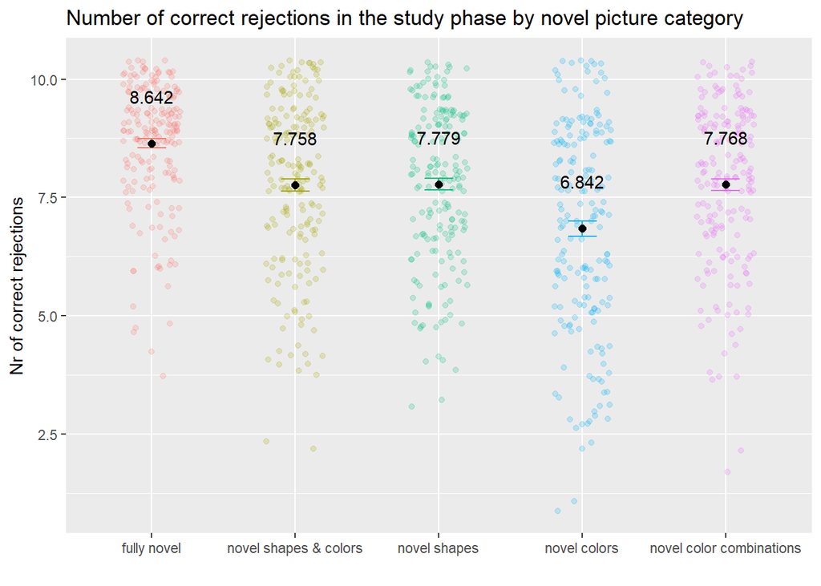

# Test phase:

Maybe responses (MEAN ± SD): 10.3052632 ± 6.7745985.

```
## [1] "A t-test to compare the number of old responses btwn old and new stim"
```

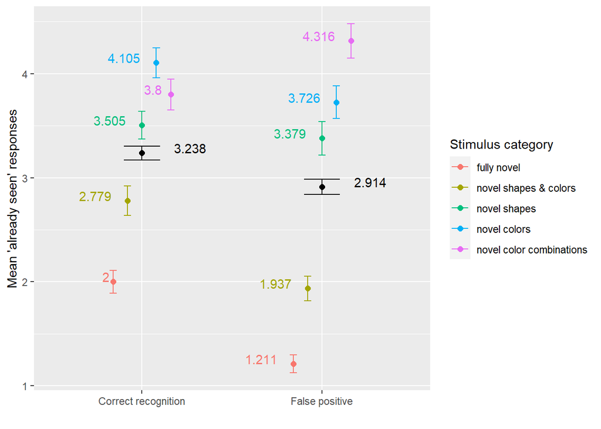

Results of the paired t-test: (t(949)=5.1592704, p = 3.0185374^{-7}, Cohen’s d = 0.1508711, 95% CI:0.0931944 - 0.2085478).

Shapiro-Wilk is significant (p = 6.6197965^{-13}).

We used a Wilcoxon sgined-rank test. Z = -5.3871776, p = 3.5786353^{-8}

## ANOVA - Corrected Recog

```
## Anova Table (Type 3 tests)
##
## Response: CorrRecog
##     Effect           df  MSE        F  ges p.value
## 1 neworder 3.78, 355.31 3.56 8.71 *** .066   <.001
## ---
## Signif. codes:  0 '***' 0.001 '**' 0.01 '*' 0.05 '+' 0.1 ' ' 1
##
## Sphericity correction method: GG
```

```
##  contrast estimate    SE df t.ratio p.value
##  A - B     -0.0526 0.233 94  -0.225  0.9994
##  A - C      0.4105 0.257 94   1.596  0.5038
##  A - D      0.6632 0.265 94   2.502  0.0988
##  A - E      1.3053 0.241 94   5.408  <.0001
##  B - C      0.4632 0.249 94   1.857  0.3478
##  B - D      0.7158 0.266 94   2.692  0.0627
##  B - E      1.3579 0.263 94   5.162  <.0001
##  C - D      0.2526 0.286 94   0.882  0.9027
##  C - E      0.8947 0.300 94   2.980  0.0294
##  D - E      0.6421 0.290 94   2.213  0.1840
##
## P value adjustment: tukey method for comparing a family of 5 estimates
```

```
##  contrast  estimate    SE df t.ratio p.value
##  linear      -3.326 0.552 94  -6.022  <.0001
##  quadratic   -1.179 0.768 94  -1.536  0.1280
##  cubic        0.126 0.583 94   0.217  0.8289
##  quartic     -1.326 1.564 94  -0.848  0.3985
```

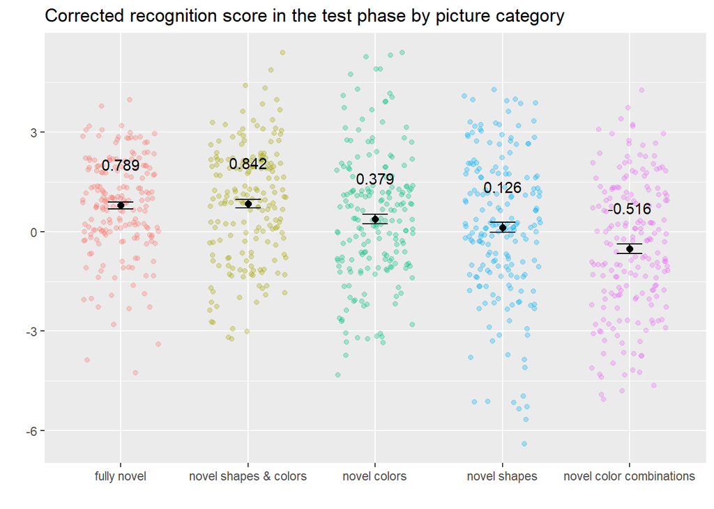

ANOVA (factor: TYPE (5 lvls)): (F[3.7799195,355.3124336] = 8.708999, p = 1.7993665^{-6}, n2G = 0.0657738).

# Mixed models

The metrics

-DTF - Difference To corresponding Familiar picture All pictures are compared to a familiar. The number of differences between the three vectors of the pictures yields a difference score.

-DTAF - mean Difference To All Familiars We calculate the difference from all prototypes and take the mean for each picture in the set.

-DTN - mean Difference To all other Novels in the same category We calculate the differences between each pair of pictures and then take the mean of these differences (19 comparisons per stim).

## Study phase

With these models i tried to assess which difference index explains familiar v novel distinction in study phase the best. As far as i understand, the model with the smallest AIC fits best to our data, which means that the mean difference from the corresponding familiar worked best here. The models all show, that the more different pictures are categorized with the highest efficacy.

```
## Generalized linear mixed model fit by maximum likelihood (Laplace
##   Approximation) [glmerMod]
##  Family: binomial  ( logit )
## Formula: st_corr ~ DTF + (1 | workerId)
##    Data: stlmm
##
##      AIC      BIC   logLik deviance df.resid
##   7878.8   7899.4  -3936.4   7872.8     7122
##
## Scaled residuals:
##     Min      1Q  Median      3Q     Max
## -4.2446 -1.0619  0.4918  0.6236  1.2370
##
## Random effects:
##  Groups   Name        Variance Std.Dev.
##  workerId (Intercept) 0.2391   0.489
## Number of obs: 7125, groups:  workerId, 95
##
## Fixed effects:
##             Estimate Std. Error z value Pr(>|z|)
## (Intercept)  0.77357    0.06169   12.54   <2e-16 ***
## DTF          0.07717    0.00623   12.39   <2e-16 ***
## ---
## Signif. codes:  0 '***' 0.001 '**' 0.01 '*' 0.05 '.' 0.1 ' ' 1
##
## Correlation of Fixed Effects:
##     (Intr)
## DTF -0.352
```

```
## Package `effects` is not available, but needed for `ggeffect()`. Either install package `effects`, or use `ggpredict()`. Calling `ggpredict()` now.FALSE
```

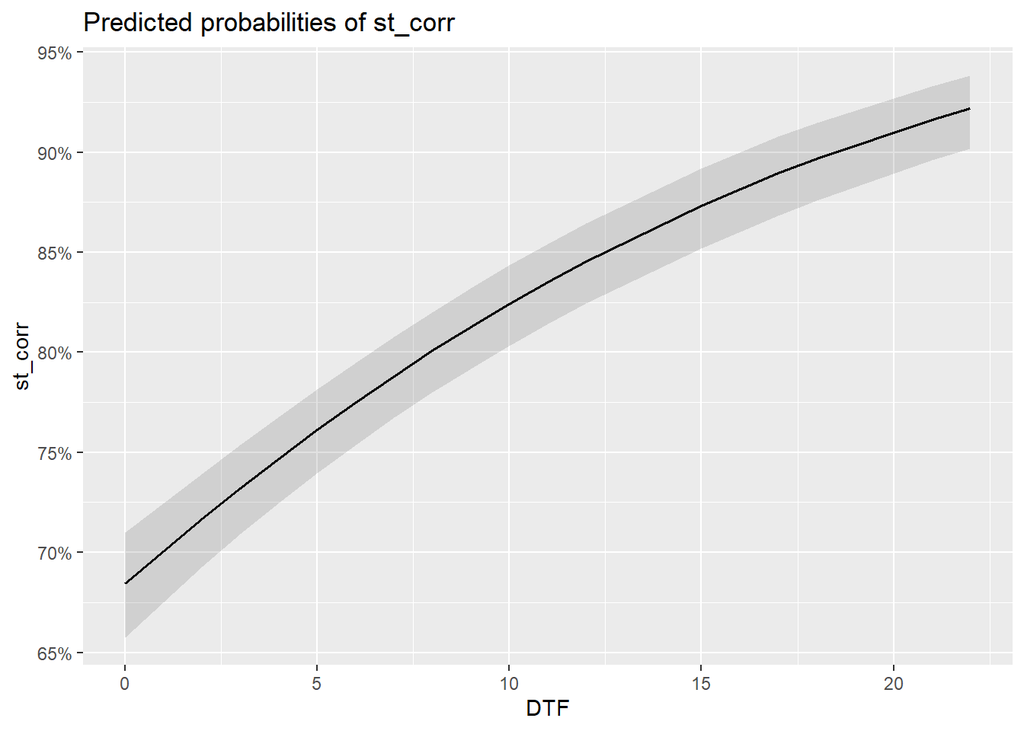

```
## Generalized linear mixed model fit by maximum likelihood (Laplace
##   Approximation) [glmerMod]
##  Family: binomial  ( logit )
## Formula: st_corr ~ DTAF + (1 | workerId)
##    Data: stlmm
##
##      AIC      BIC   logLik deviance df.resid
##   7890.1   7910.8  -3942.1   7884.1     7122
##
## Scaled residuals:
##     Min      1Q  Median      3Q     Max
## -3.5332 -1.0132  0.4774  0.6116  1.3203
##
## Random effects:
##  Groups   Name        Variance Std.Dev.
##  workerId (Intercept) 0.2396   0.4894
## Number of obs: 7125, groups:  workerId, 95
##
## Fixed effects:
##             Estimate Std. Error z value Pr(>|z|)
## (Intercept) 0.641390   0.065991   9.719   <2e-16 ***
## DTAF        0.054912   0.004247  12.928   <2e-16 ***
## ---
## Signif. codes:  0 '***' 0.001 '**' 0.01 '*' 0.05 '.' 0.1 ' ' 1
##
## Correlation of Fixed Effects:
##      (Intr)
## DTAF -0.483
```

```
## Package `effects` is not available, but needed for `ggeffect()`. Either install package `effects`, or use `ggpredict()`. Calling `ggpredict()` now.FALSE
```

```
## Data were 'prettified'. Consider using `terms="DTAF [all]"` to get smooth plots.
```

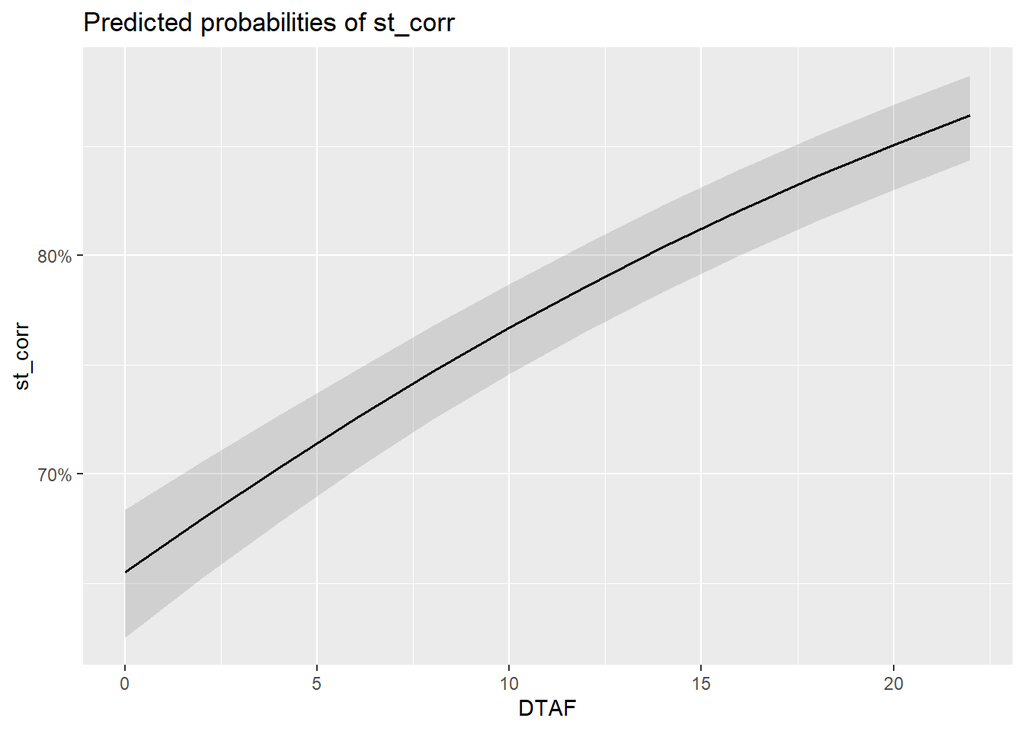

```
## Generalized linear mixed model fit by maximum likelihood (Laplace
##   Approximation) [glmerMod]
##  Family: binomial  ( logit )
## Formula: st_corr ~ DTAN + (1 | workerId)
##    Data: stlmm
##
##      AIC      BIC   logLik deviance df.resid
##   7908.0   7928.7  -3951.0   7902.0     7122
##
## Scaled residuals:
##     Min      1Q  Median      3Q     Max
## -3.5995 -1.0234  0.4798  0.6145  1.3108
##
## Random effects:
##  Groups   Name        Variance Std.Dev.
##  workerId (Intercept) 0.2382   0.4881
## Number of obs: 7125, groups:  workerId, 95
##
## Fixed effects:
##             Estimate Std. Error z value Pr(>|z|)
## (Intercept) 0.651607   0.066393   9.814   <2e-16 ***
## DTAN        0.053665   0.004356  12.318   <2e-16 ***
## ---
## Signif. codes:  0 '***' 0.001 '**' 0.01 '*' 0.05 '.' 0.1 ' ' 1
##
## Correlation of Fixed Effects:
##      (Intr)
## DTAN -0.496
```

```
## Package `effects` is not available, but needed for `ggeffect()`. Either install package `effects`, or use `ggpredict()`. Calling `ggpredict()` now.FALSE
```

```
## Data were 'prettified'. Consider using `terms="DTAN [all]"` to get smooth plots.
```

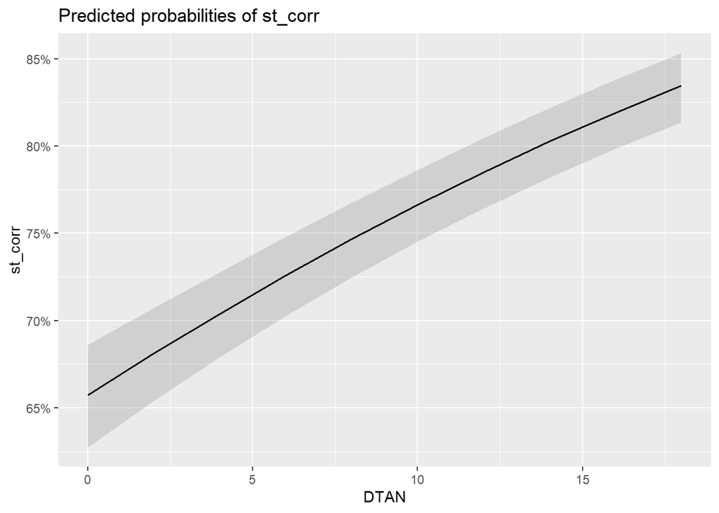

|  | st_corr |  |  |  | st_corr |  |  |  | st_corr |  |  |  |
| --- | --- | --- | --- | --- | --- | --- | --- | --- | --- | --- | --- | --- |
| Predictors | Log-Odds | std. Error | CI | p | Log-Odds | std. Error | CI | p | Log-Odds | std. Error | CI | p |
| (Intercept) | 0.77 | 0.06 | 0.65 – 0.89 | **<0.001** | 0.64 | 0.07 | 0.51 – 0.77 | **<0.001** | 0.65 | 0.07 | 0.52 – 0.78 | **<0.001** |
| DTF | 0.08 | 0.01 | 0.06 – 0.09 | **<0.001** |  |  |  |  |  |  |  |  |
| DTAF |  |  |  |  | 0.05 | 0.00 | 0.05 – 0.06 | **<0.001** |  |  |  |  |
| DTAN |  |  |  |  |  |  |  |  | 0.05 | 0.00 | 0.05 – 0.06 | **<0.001** |
| Random Effects |  |  |  |  |  |  |  |  |  |  |  |  |
| σ<sup>2</sup> | 3.29 |  |  |  | 3.29 |  |  |  | 3.29 |  |  |  |
| τ<sub>00</sub> | 0.24 <sub>workerId</sub> |  |  |  | 0.24 <sub>workerId</sub> |  |  |  | 0.24 <sub>workerId</sub> |  |  |  |
| ICC | 0.07 |  |  |  | 0.07 |  |  |  | 0.07 |  |  |  |
| N | 95 <sub>workerId</sub> |  |  |  | 95 <sub>workerId</sub> |  |  |  | 95 <sub>workerId</sub> |  |  |  |
| Observations | 7125 |  |  |  | 7125 |  |  |  | 7125 |  |  |  |
| Marginal R<sup>2</sup> / Conditional R<sup>2</sup> | 0.048 / 0.112 |  |  |  | 0.035 / 0.101 |  |  |  | 0.031 / 0.096 |  |  |  |
| AIC | 7878.812 |  |  |  | 7890.147 |  |  |  | 7908.040 |  |  |  |
| AICc | 7878.816 |  |  |  | 7890.150 |  |  |  | 7908.043 |  |  |  |

## Test phase

### Models #1 - without random slope term

Logistic mixed regression for the test phase. Does difference from prototypes or familiarity/novelty have an effect on correct categorization in the test phase?

```
## Generalized linear mixed model fit by maximum likelihood (Laplace
##   Approximation) [glmerMod]
##  Family: binomial  ( logit )
## Formula: rt_resp ~ DTF * tq + (1 | workerId)
##    Data: tdlmm
##
##      AIC      BIC   logLik deviance df.resid
##   9293.3   9328.0  -4641.7   9283.3     7651
##
## Scaled residuals:
##     Min      1Q  Median      3Q     Max
## -2.3218 -0.7644 -0.4557  0.9291  6.4671
##
## Random effects:
##  Groups   Name        Variance Std.Dev.
##  workerId (Intercept) 0.4205   0.6485
## Number of obs: 7656, groups:  workerId, 95
##
## Fixed effects:
##              Estimate Std. Error z value Pr(>|z|)
## (Intercept)  0.327317   0.092358   3.544 0.000394 ***
## DTF         -0.142567   0.008934 -15.959  < 2e-16 ***
## tqold       -0.256431   0.085512  -2.999 0.002711 **
## DTF:tqold    0.061001   0.011427   5.338 9.38e-08 ***
## ---
## Signif. codes:  0 '***' 0.001 '**' 0.01 '*' 0.05 '.' 0.1 ' ' 1
##
## Correlation of Fixed Effects:
##           (Intr) DTF    tqold
## DTF       -0.565
## tqold     -0.517  0.611
## DTF:tqold  0.442 -0.779 -0.806
```

```
## Package `effects` is not available, but needed for `ggeffect()`. Either install package `effects`, or use `ggpredict()`. Calling `ggpredict()` now.FALSE
```

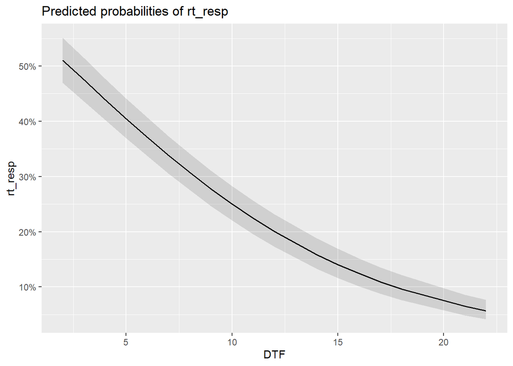

```
## Package `effects` is not available, but needed for `ggeffect()`. Either install package `effects`, or use `ggpredict()`. Calling `ggpredict()` now.FALSE
```

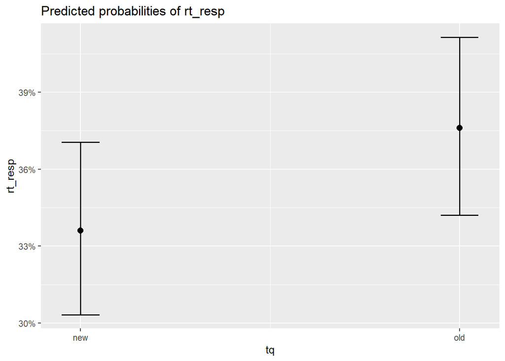

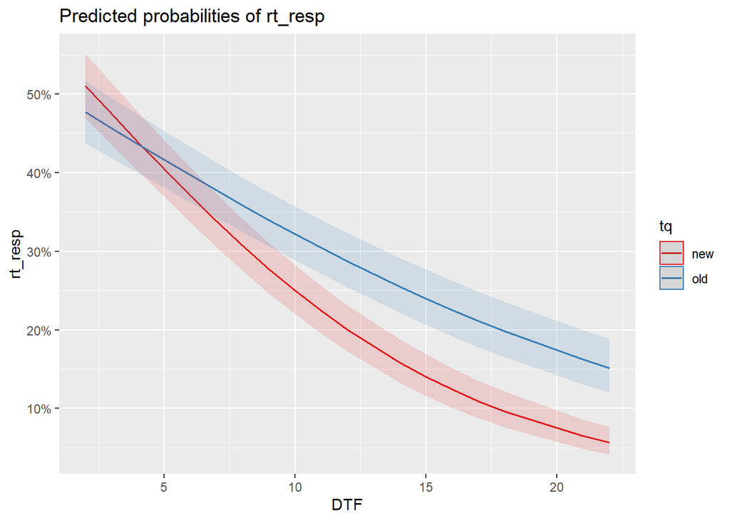

```
## Generalized linear mixed model fit by maximum likelihood (Laplace
##   Approximation) [glmerMod]
##  Family: binomial  ( logit )
## Formula: rt_resp ~ DTAF * tq + (1 | workerId)
##    Data: tdlmm
##
##      AIC      BIC   logLik deviance df.resid
##   9309.1   9343.8  -4649.6   9299.1     7651
##
## Scaled residuals:
##     Min      1Q  Median      3Q     Max
## -2.2303 -0.7677 -0.4573  0.9363  4.9584
##
## Random effects:
##  Groups   Name        Variance Std.Dev.
##  workerId (Intercept) 0.4149   0.6442
## Number of obs: 7656, groups:  workerId, 95
##
## Fixed effects:
##             Estimate Std. Error z value Pr(>|z|)
## (Intercept)  2.44032    0.20361  11.985  < 2e-16 ***
## DTAF        -0.23826    0.01520 -15.676  < 2e-16 ***
## tqold       -0.88449    0.25654  -3.448 0.000565 ***
## DTAF:tqold   0.08011    0.02009   3.988 6.66e-05 ***
## ---
## Signif. codes:  0 '***' 0.001 '**' 0.01 '*' 0.05 '.' 0.1 ' ' 1
##
## Correlation of Fixed Effects:
##            (Intr) DTAF   tqold
## DTAF       -0.928
## tqold      -0.708  0.734
## DTAF:tqold  0.700 -0.753 -0.980
```

```
## Package `effects` is not available, but needed for `ggeffect()`. Either install package `effects`, or use `ggpredict()`. Calling `ggpredict()` now.FALSE
```

```
## Data were 'prettified'. Consider using `terms="DTAF [all]"` to get smooth plots.
```

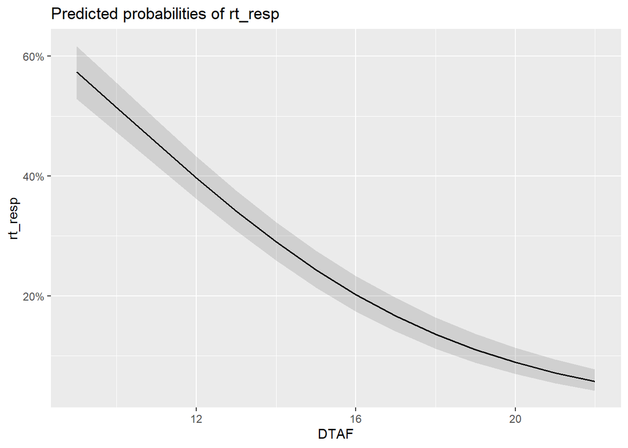

```
## Package `effects` is not available, but needed for `ggeffect()`. Either install package `effects`, or use `ggpredict()`. Calling `ggpredict()` now.FALSE
## Data were 'prettified'. Consider using `terms="DTAF [all]"` to get smooth plots.
```

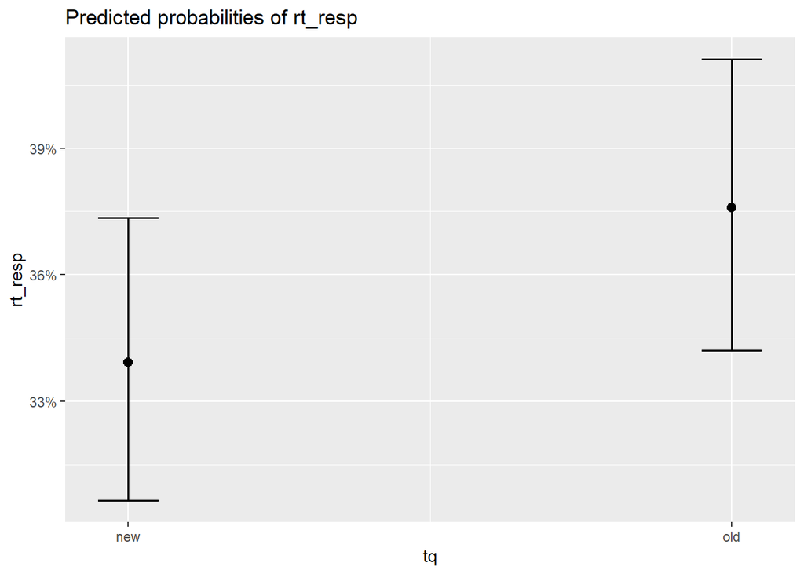

```
## Data were 'prettified'. Consider using `terms="DTAF [all]"` to get smooth plots.
```

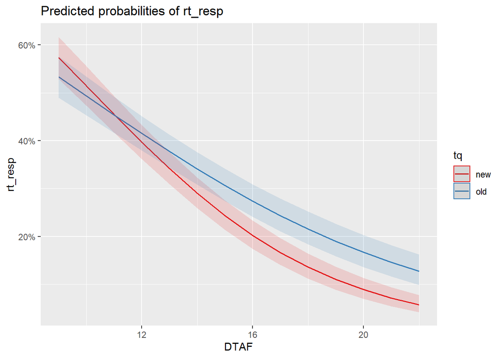

```
## Generalized linear mixed model fit by maximum likelihood (Laplace
##   Approximation) [glmerMod]
##  Family: binomial  ( logit )
## Formula: rt_resp ~ DTAN * tq + (1 | workerId)
##    Data: tdlmm
##
##      AIC      BIC   logLik deviance df.resid
##   9373.3   9408.0  -4681.7   9363.3     7651
##
## Scaled residuals:
##     Min      1Q  Median      3Q     Max
## -2.3677 -0.7551 -0.4830  0.9415  5.5459
##
## Random effects:
##  Groups   Name        Variance Std.Dev.
##  workerId (Intercept) 0.4143   0.6437
## Number of obs: 7656, groups:  workerId, 95
##
## Fixed effects:
##             Estimate Std. Error z value Pr(>|z|)
## (Intercept)  3.39055    0.27300  12.420  < 2e-16 ***
## DTAN        -0.31491    0.02093 -15.045  < 2e-16 ***
## tqold       -0.94269    0.36249  -2.601  0.00931 **
## DTAN:tqold   0.08637    0.02848   3.033  0.00242 **
## ---
## Signif. codes:  0 '***' 0.001 '**' 0.01 '*' 0.05 '.' 0.1 ' ' 1
##
## Correlation of Fixed Effects:
##            (Intr) DTAN   tqold
## DTAN       -0.961
## tqold      -0.706  0.720
## DTAN:tqold  0.703 -0.731 -0.990
## optimizer (Nelder_Mead) convergence code: 0 (OK)
## Model failed to converge with max|grad| = 0.00267567 (tol = 0.002, component 1)
```

```
## Package `effects` is not available, but needed for `ggeffect()`. Either install package `effects`, or use `ggpredict()`. Calling `ggpredict()` now.FALSE
```

```
## Data were 'prettified'. Consider using `terms="DTAN [all]"` to get smooth plots.
```

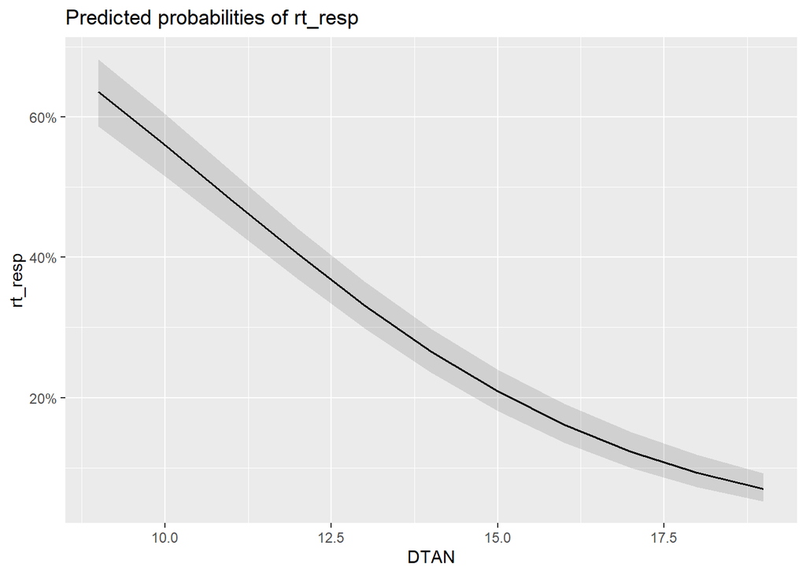

```
## Package `effects` is not available, but needed for `ggeffect()`. Either install package `effects`, or use `ggpredict()`. Calling `ggpredict()` now.FALSE
## Data were 'prettified'. Consider using `terms="DTAN [all]"` to get smooth plots.
```

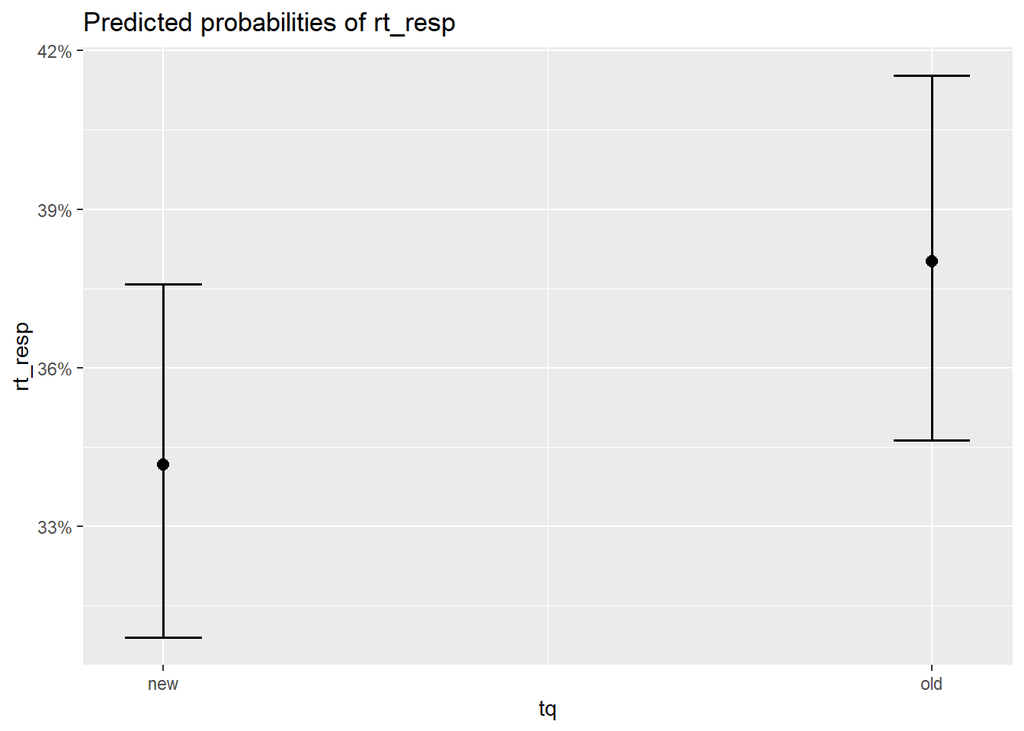

```
## Data were 'prettified'. Consider using `terms="DTAN [all]"` to get smooth plots.
```

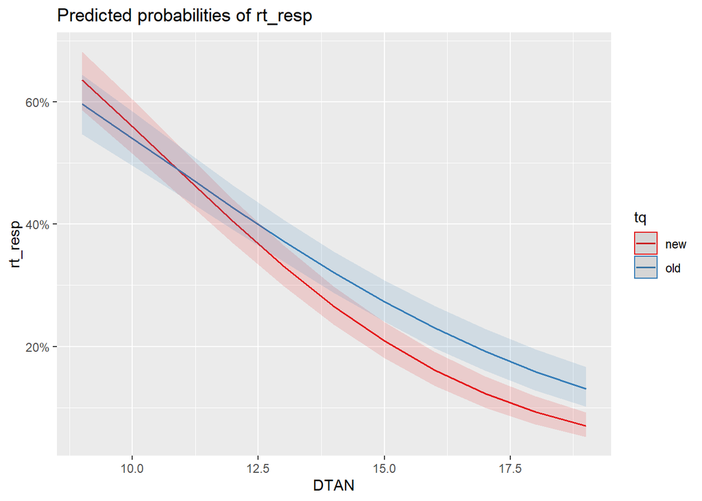

|  | rt_resp |  |  |  | rt_resp |  |  |  | rt_resp |  |  |  |
| --- | --- | --- | --- | --- | --- | --- | --- | --- | --- | --- | --- | --- |
| Predictors | Log-Odds | std. Error | CI | p | Log-Odds | std. Error | CI | p | Log-Odds | std. Error | CI | p |
| (Intercept) | 0.33 | 0.09 | 0.15 – 0.51 | **<0.001** | 2.44 | 0.20 | 2.04 – 2.84 | **<0.001** | 3.39 | 0.27 | 2.86 – 3.93 | **<0.001** |
| DTF | -0.14 | 0.01 | -0.16 – -0.13 | **<0.001** |  |  |  |  |  |  |  |  |
| tq [old] | -0.26 | 0.09 | -0.42 – -0.09 | **0.003** | -0.88 | 0.26 | -1.39 – -0.38 | **0.001** | -0.94 | 0.36 | -1.65 – -0.23 | **0.009** |
| DTF * tq [old] | 0.06 | 0.01 | 0.04 – 0.08 | **<0.001** |  |  |  |  |  |  |  |  |
| DTAF |  |  |  |  | -0.24 | 0.02 | -0.27 – -0.21 | **<0.001** |  |  |  |  |
| DTAF * tq [old] |  |  |  |  | 0.08 | 0.02 | 0.04 – 0.12 | **<0.001** |  |  |  |  |
| DTAN |  |  |  |  |  |  |  |  | -0.31 | 0.02 | -0.36 – -0.27 | **<0.001** |
| DTAN * tq [old] |  |  |  |  |  |  |  |  | 0.09 | 0.03 | 0.03 – 0.14 | **0.002** |
| Random Effects |  |  |  |  |  |  |  |  |  |  |  |  |
| σ<sup>2</sup> | 3.29 |  |  |  | 3.29 |  |  |  | 3.29 |  |  |  |
| τ<sub>00</sub> | 0.42 <sub>workerId</sub> |  |  |  | 0.41 <sub>workerId</sub> |  |  |  | 0.41 <sub>workerId</sub> |  |  |  |
| ICC | 0.11 |  |  |  | 0.11 |  |  |  | 0.11 |  |  |  |
| N | 95 <sub>workerId</sub> |  |  |  | 95 <sub>workerId</sub> |  |  |  | 95 <sub>workerId</sub> |  |  |  |
| Observations | 7656 |  |  |  | 7656 |  |  |  | 7656 |  |  |  |
| Marginal R<sup>2</sup> / Conditional R<sup>2</sup> | 0.099 / 0.201 |  |  |  | 0.091 / 0.193 |  |  |  | 0.071 / 0.175 |  |  |  |
| AIC | 9293.306 |  |  |  | 9309.108 |  |  |  | 9373.325 |  |  |  |
| AICc | 9293.314 |  |  |  | 9309.116 |  |  |  | 9373.333 |  |  |  |